# Кластерный анализ. Азия.

Владимир Шаталов

29 сентября 2016 г.

В данной работе проведен кластерный анализ стран Азии по экономическим показателям. Данные для анализа были взяты с сайта [TRADINGECONOMICS](http://www.tradingeconomics.com).

```r
knitr::opts_chunk$set(fih.height=30,fig.width=10,fig.align="center")
```

Загрузим наши данные и библиотеки, которыми будем пользоваться при работе, предварительно их скачав.

```r
library(ggplot2)
library(gridExtra)
library(dendextend)
library(dplyr)
df<-read.table("D:\\AsiaClust.csv",header=T,sep=";",dec=",")
```

Пару слов о том как выбирались показатели для анализа.

- Во-первых, совокупность параметров должна адекватно отражать экономическое состояние страны.
- Во-вторых, желательно отсутствие пропущенных значений,так как во многих столбцах пропущено слишком много значений и заменить их средним или медианой, на мой взгляд неправильное решение: логичнее попробовать их предсказать по имеющимся данным, либо взять из других источников.

Посмотрим, на данные.

```r
knitr::kable(df,digits=2)
```

| Countries | GDP | GDP.YoY | Inflation.rate | Jobless.rate | Population |
| --- | --- | --- | --- | --- | --- |
| China | 10866 | 0.07 | 0.01 | 0.04 | 1374.62 |
| Japan | 4123 | 0.01 | 0.00 | 0.03 | 126.82 |
| India | 2074 | 0.07 | 0.05 | 0.05 | 1254.02 |
| South Korea | 1378 | 0.03 | 0.00 | 0.04 | 50.60 |
| Indonesia | 862 | 0.05 | 0.03 | 0.06 | 255.46 |
| Saudi Arabia | 646 | 0.03 | 0.03 | 0.06 | 31.52 |
| Taiwan | 524 | 0.01 | 0.01 | 0.04 | 23.49 |
| Iran | 425 | 0.01 | 0.09 | 0.12 | 78.80 |
| Thailand | 395 | 0.04 | 0.00 | 0.01 | 67.96 |
| United Arab Emirates | 370 | 0.03 | 0.02 | 0.04 | 9.16 |
| Hong Kong | 310 | 0.02 | 0.04 | 0.03 | 7.30 |
| Israel | 296 | 0.03 | -0.01 | 0.05 | 8.46 |
| Malaysia | 296 | 0.04 | 0.02 | 0.04 | 31.20 |
| Singapore | 293 | 0.02 | 0.00 | 0.02 | 5.54 |
| Philippines | 292 | 0.07 | 0.02 | 0.05 | 102.20 |
| Pakistan | 270 | 0.04 | 0.04 | 0.06 | 189.87 |
| Bangladesh | 195 | 0.07 | 0.05 | 0.04 | 157.90 |
| Vietnam | 194 | 0.06 | 0.03 | 0.02 | 91.70 |
| Kazakhstan | 184 | 0.00 | 0.18 | 0.05 | 17.40 |
| Iraq | 169 | 0.02 | 0.00 | 0.16 | 35.87 |
| Qatar | 167 | 0.01 | 0.03 | 0.00 | 2.34 |
| Kuwait | 113 | 0.02 | 0.03 | 0.02 | 3.89 |
| Sri Lanka | 82 | 0.03 | 0.04 | 0.04 | 20.96 |
| Syria | 74 | -0.02 | 0.48 | 0.15 | 22.35 |
| Oman | 70 | -0.14 | 0.01 | 0.07 | 4.15 |
| Uzbekistan | 67 | 0.08 | 0.06 | 0.11 | 31.19 |
| Myanmar | 65 | 0.07 | 0.11 | 0.04 | 53.90 |
| Azerbaijan | 53 | -0.03 | 0.11 | 0.05 | 9.59 |
| Lebanon | 47 | 0.01 | -0.01 | 0.06 | 4.65 |
| Macau | 46 | -0.07 | 0.02 | 0.02 | 0.64 |
| Jordan | 38 | 0.02 | -0.01 | 0.15 | 9.53 |
| Turkmenistan | 37 | 0.07 | 0.07 | 0.11 | 5.37 |
| Yemen | 37 | -0.28 | 0.09 | 0.29 | 26.83 |
| Bahrain | 32 | 0.03 | 0.03 | 0.04 | 1.37 |
| Nepal | 21 | 0.01 | 0.10 | 0.03 | 28.51 |
| Afghanistan | 19 | 0.02 | 0.07 | 0.40 | 27.10 |
| Cambodia | 18 | 0.07 | 0.03 | 0.01 | 15.60 |
| Brunei | 15 | 0.04 | -0.01 | 0.07 | 0.42 |
| Georgia | 14 | 0.03 | 0.01 | 0.12 | 3.72 |
| Mongolia | 12 | 0.01 | 0.00 | 0.10 | 3.06 |
| Laos | 12 | 0.07 | 0.02 | 0.01 | 6.80 |
| Armenia | 11 | 0.02 | -0.02 | 0.18 | 2.99 |
| Tajikistan | 8 | 0.07 | 0.06 | 0.02 | 8.48 |
| Kyrgyzstan | 7 | -0.02 | 0.01 | 0.02 | 5.89 |
| Palestine | 7 | 0.08 | 0.00 | 0.27 | 4.68 |
| Maldives | 3 | 0.05 | 0.00 | 0.12 | 0.35 |
| Bhutan | 2 | 0.06 | 0.03 | 0.03 | 0.78 |
| East Timor | 1 | 0.04 | -0.02 | 0.11 | 1.24 |

```r
df1<-df
df1$GDP.Pop<-df1$GDP/df1$Population
names(df1)[7]<-"GDP/Pop"
df1<-df1[,-6]
df2<-df1
df2[,2:6]<-scale(df2[,2:6])
```

Представленный выше код нормирует переменные, а также заменяет столбец с численностью населения на столбец с ВВП на душу населения. Посмотрим на то, что получилось:

```r
knitr::kable(df2[1:10,],digits=2)
```

| Countries | GDP | GDP.YoY | Inflation.rate | Jobless.rate | GDP/Pop |
| --- | --- | --- | --- | --- | --- |
| China | 6.20 | 0.80 | -0.40 | -0.46 | -0.31 |
| Japan | 2.16 | -0.21 | -0.53 | -0.59 | 1.05 |
| India | 0.93 | 0.80 | 0.12 | -0.33 | -0.65 |
| South Korea | 0.51 | 0.13 | -0.53 | -0.46 | 0.76 |
| Indonesia | 0.20 | 0.46 | -0.14 | -0.20 | -0.56 |
| Saudi Arabia | 0.07 | 0.13 | -0.14 | -0.20 | 0.39 |
| Taiwan | 0.00 | -0.21 | -0.40 | -0.46 | 0.49 |
| Iran | -0.06 | -0.21 | 0.65 | 0.56 | -0.45 |
| Thailand | -0.08 | 0.30 | -0.53 | -0.84 | -0.42 |
| United Arab Emirates | -0.09 | 0.13 | -0.27 | -0.46 | 1.49 |

Можем приступить к кластерному анализу.

## Иерархическая кластеризация

Проведем кластеризацию трижды, по-разному вычисляя расстояния между кластерами.

```r
hclustWard <- hclust(dist(df2[,2:6]), method="ward.D")
hclustComplete<- hclust(dist(df2[,2:6]), method="complete")
hclustSingle<- hclust(dist(df2[,2:6]), method="single")
```

Посмотрим на дендрограммы

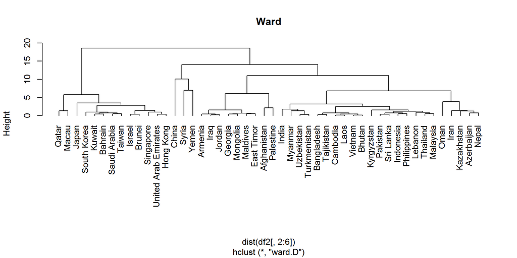

```r
plot(hclustWard, labels=df2[ ,1],hang=-1,main="Ward")
```

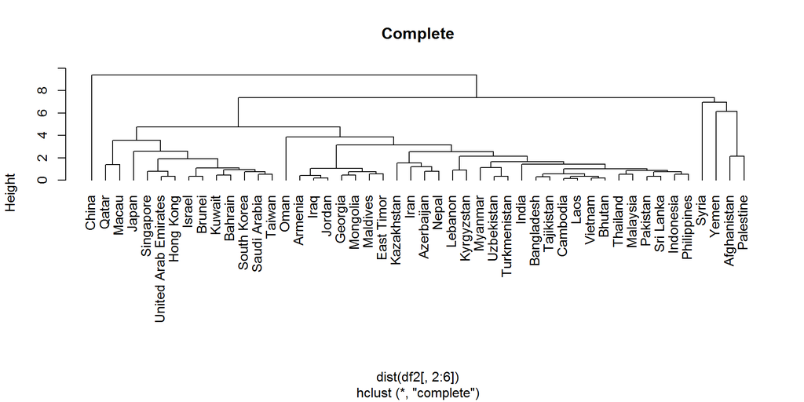

```r
plot(hclustComplete,labels=df2[ ,1],hang=-1,main="Complete")
```

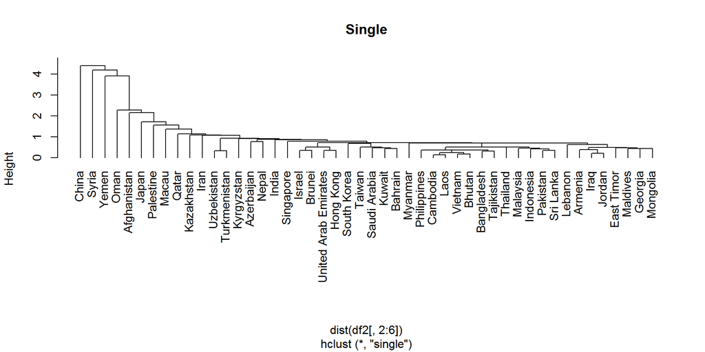

```r
plot(hclustSingle,labels=df2[ ,1],hang=-1,main="Single")
```

Как видно метод Single не подходит в данном случае для кластеризации. Построим каменистую осыпь для метода Варда

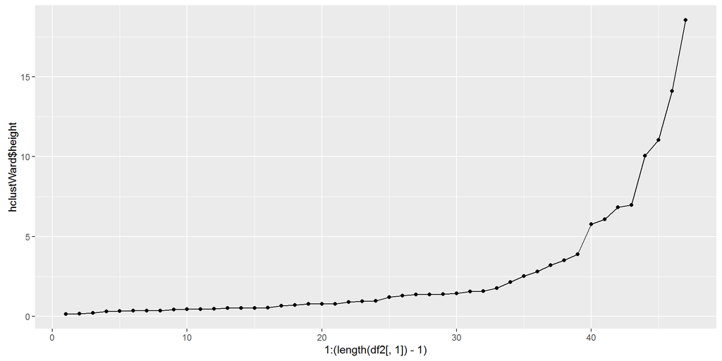

```r
qplot(1:(length(df2[ ,1])-1),hclustWard$height,geom=c("line","point"))
```

В зависимости от того, насколько детальные требуются результаты страны можно разбить на 5 или 9 кластеров. Посмотрим, как в этом случае будет выглядеть дендрограмма

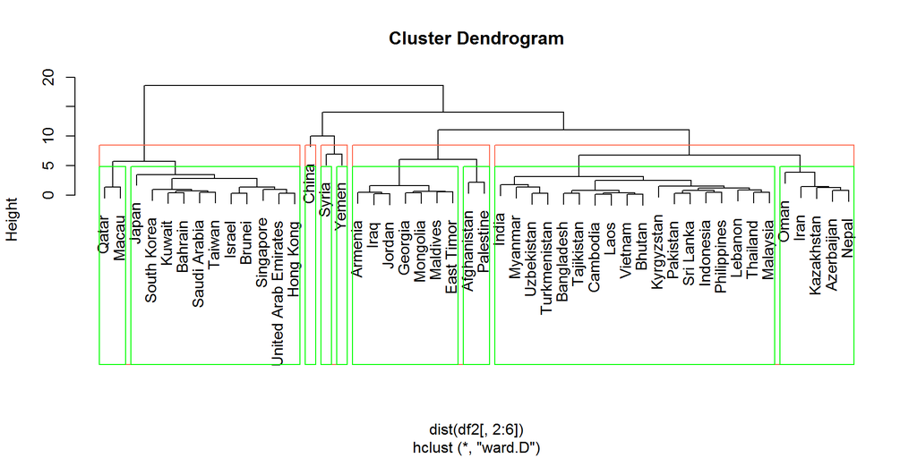

```r
plot(hclustWard, labels=df2[ ,1])
rect.hclust(hclustWard, k=5, border="tomato")
rect.hclust(hclustWard, k=9, border="green")
```

Сделаем то же самое для другого метода.

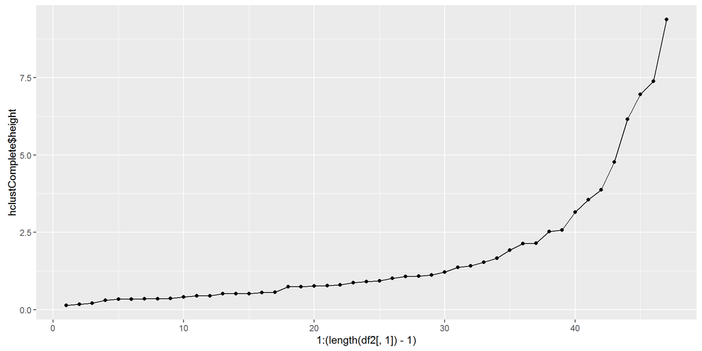

```r
qplot(1:(length(df2[ ,1])-1),hclustComplete$height,geom=c("line","point"))
```

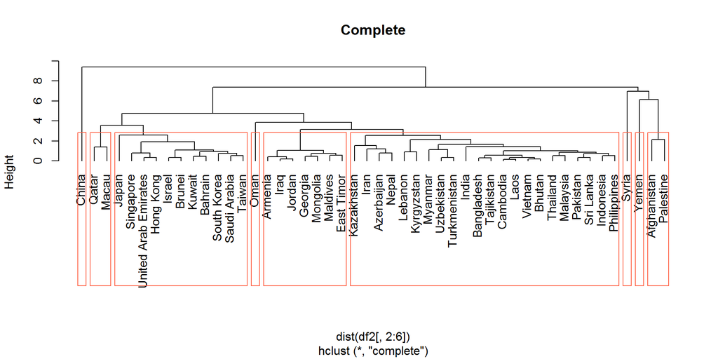

```r
plot(hclustComplete,labels=df2[ ,1],hang=-1,main="Complete")
rect.hclust(hclustComplete, k=9, border="tomato")
```

Здесь можно выделить 9 кластеров.  
Рассмотрим какие кластеры получились, когда применялся метод Варда. Но предварительно расчитаем средние значения всех показателей и медианы.

```r
means<-apply(df1[,2:6],2,mean)
medians<-apply(df1[,2:6],2,median)
means
```

```
##            GDP        GDP.YoY Inflation.rate   Jobless.rate        GDP/Pop
##   525.83333333     0.02229167     0.04062500     0.07604167    13.49606818
```

```r
medians
```

```
##            GDP        GDP.YoY Inflation.rate   Jobless.rate        GDP/Pop
##      72.000000       0.030000       0.025000       0.050000       4.349433
```

### Кластер 1

```r
groupsW5 <- cutree(hclustWard, k=5)
colMeans(df1[groupsW5==1, 2:6])
```

```
##            GDP        GDP.YoY Inflation.rate   Jobless.rate        GDP/Pop
##    10866.00000        0.07000        0.01000        0.04000        7.90473
```

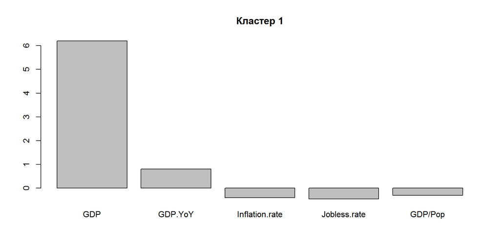

```r
barplot(colMeans(df2[groupsW5==1, 2:6]),main="Кластер 1")
```

```r
df1[groupsW5==1,1]
```

```
## [1] China
## 48 Levels: Afghanistan  Armenia  Azerbaijan  Bahrain  ... Yemen
```

Как видим, Китай стоит особняком за счеет своего огромного ВВП, более чем в 2 раза превышающего показатель ближайшего конкурента, в 20 раз превышающего среднее значение и в 150 раз большего медианы. При этом уровень ВВП на душу на селения довольно средний для региона.

### Кластер 2

```r
colMeans(df1[groupsW5==2, 2:6])
```

```
##            GDP        GDP.YoY Inflation.rate   Jobless.rate        GDP/Pop
##   639.46153846     0.01615385     0.01461538     0.03538462    38.81880636
```

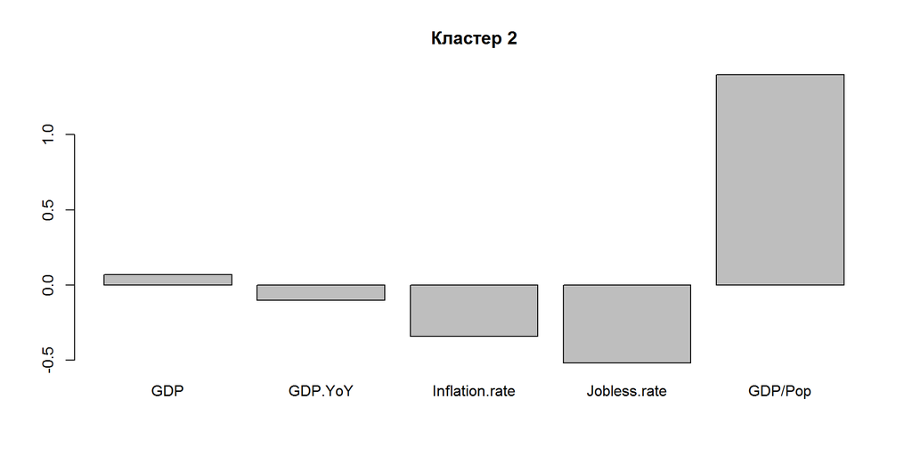

```r
barplot(colMeans(df2[groupsW5==2, 2:6]),main="Кластер 2")
```

```r
df1[groupsW5==2,1]
```

```
##  [1] Japan                 South Korea           Saudi Arabia
##  [4] Taiwan                United Arab Emirates  Hong Kong
##  [7] Israel                Singapore             Qatar
## [10] Kuwait                Macau                 Bahrain
## [13] Brunei
## 48 Levels: Afghanistan  Armenia  Azerbaijan  Bahrain  ... Yemen
```

В данный кластер попали экономически развитые страны с самым высоким уровнем ВВП на душу населения, и низкими инфляцией и уровнем безработицы в регионе.

### Кластер 3

```r
colMeans(df1[groupsW5==3, 2:6])
```

```
##            GDP        GDP.YoY Inflation.rate   Jobless.rate        GDP/Pop
##   246.78260870     0.03478261     0.05000000     0.04782609     4.30150111
```

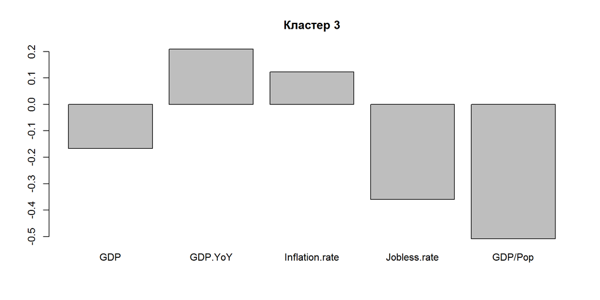

```r
barplot(colMeans(df2[groupsW5==3, 2:6]),main="Кластер 3")
```

```r
df1[groupsW5==3,1]
```

```
##  [1] India         Indonesia     Iran          Thailand      Malaysia
##  [6] Philippines   Pakistan      Bangladesh    Vietnam       Kazakhstan
## [11] Sri Lanka     Oman          Uzbekistan    Myanmar       Azerbaijan
## [16] Lebanon       Turkmenistan  Nepal         Cambodia      Laos
## [21] Tajikistan    Kyrgyzstan    Bhutan
## 48 Levels: Afghanistan  Armenia  Azerbaijan  Bahrain  ... Yemen
```

В этот кластер попало довольно много стран и средние показатели по кластеру многого о них не скажут. Но при этом почти у всех у них невысокий показатель ВВП на душу населения. Но при этом намечен рост ВВП.Хотя сам ВВП небольшой. Если не учитываться вклад Индии, то средний ВВП будет равен 163.73. Кластеризация до 9 кластеров как раз и поможет уточнить данные по этим странам.

### Кластер 4

```r
colMeans(df1[groupsW5==4, 2:6])
```

```
##            GDP        GDP.YoY Inflation.rate   Jobless.rate        GDP/Pop
##   30.444444444    0.032222222    0.003333333    0.178888889    3.515279908
```

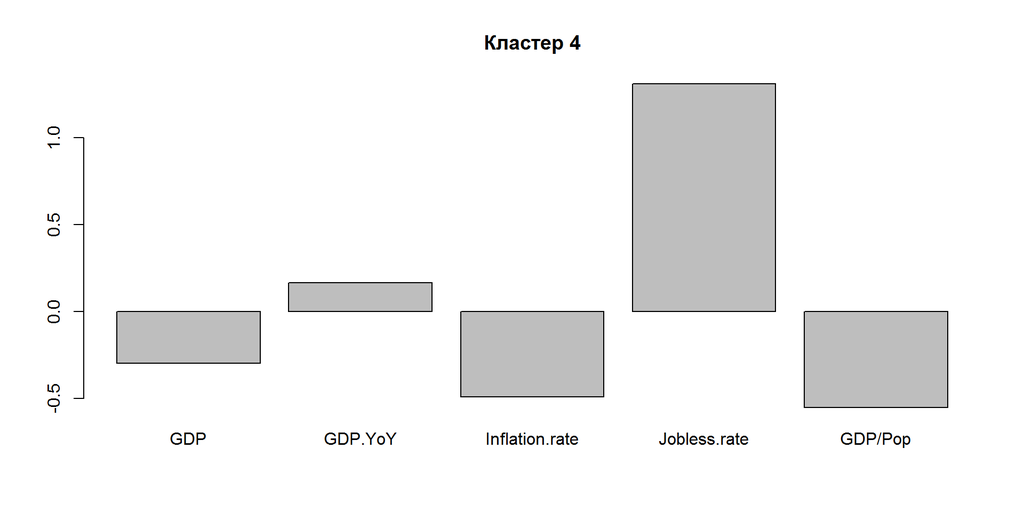

```r
barplot(colMeans(df2[groupsW5==4, 2:6]),main="Кластер 4")
```

```r
df1[groupsW5==4,1]
```

```
## [1] Iraq         Jordan       Afghanistan  Georgia      Mongolia
## [6] Armenia      Palestine    Maldives     East Timor
## 48 Levels: Afghanistan  Armenia  Azerbaijan  Bahrain  ... Yemen
```

В кластер попали страны с явными проблемами на рынке труда. Если в предыдущем кластере уровень безработицы был ниже среднего, то здесь наоборот заметно выше.

### Кластер 5

```r
colMeans(df1[groupsW5==5, 2:6])
```

```
##            GDP        GDP.YoY Inflation.rate   Jobless.rate        GDP/Pop
##      55.500000      -0.150000       0.285000       0.220000       2.345008
```

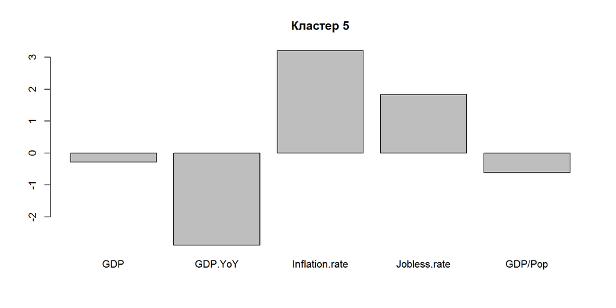

```r
barplot(colMeans(df2[groupsW5==5, 2:6]),main="Кластер 5")
```

```r
df1[groupsW5==5,1]
```

```
## [1] Syria  Yemen
## 48 Levels: Afghanistan  Armenia  Azerbaijan  Bahrain  ... Yemen
```

В эту группу попали страны с самыми серьезными экономическими проблемами в Азии,о чем можно судить прежде всего по огромному снижению ВВП, большой инфляцией и высоим уровнем безработицы. В первую очередь это обусловлено вооруженными конфликтами в этих странах. К тому же в Йемене большую часть экономики составляет нефтедобывающий сектор. Мало того, что цена на нефть заметно упала, так еще и запасы нефти в стране сильно сокращаются.

Дальше сравним какие кластеры получились в методах Варда и Complete, когда мы делим страны на 9 кластеров.Кластеры, которые совпадают с уже рассмотренными, будем пропускать.

```r
groupsC9 <- cutree(hclustComplete, k=9)
groupsW9 <- cutree(hclustWard, k=9)
```

```r
df1[groupsC9==3,1]
```

```
##  [1] India         Indonesia     Iran          Thailand      Malaysia
##  [6] Philippines   Pakistan      Bangladesh    Vietnam       Kazakhstan
## [11] Sri Lanka     Uzbekistan    Myanmar       Azerbaijan    Lebanon
## [16] Turkmenistan  Nepal         Cambodia      Laos          Tajikistan
## [21] Kyrgyzstan    Bhutan
## 48 Levels: Afghanistan  Armenia  Azerbaijan  Bahrain  ... Yemen
```

```r
df1[groupsW9==3,1]
```

```
##  [1] India         Indonesia     Thailand      Malaysia      Philippines
##  [6] Pakistan      Bangladesh    Vietnam       Sri Lanka     Uzbekistan
## [11] Myanmar       Lebanon       Turkmenistan  Cambodia      Laos
## [16] Tajikistan    Kyrgyzstan    Bhutan
## 48 Levels: Afghanistan  Armenia  Azerbaijan  Bahrain  ... Yemen
```

```r
colMeans(df1[groupsC9==3, 2:6])
```

```
##            GDP        GDP.YoY Inflation.rate   Jobless.rate        GDP/Pop
##   254.81818182     0.04272727     0.05181818     0.04681818     3.73032071
```

```r
colMeans(df1[groupsW9==3, 2:6])
```

```
##            GDP        GDP.YoY Inflation.rate   Jobless.rate        GDP/Pop
##   273.50000000     0.05277778     0.03666667     0.04333333     3.32420933
```

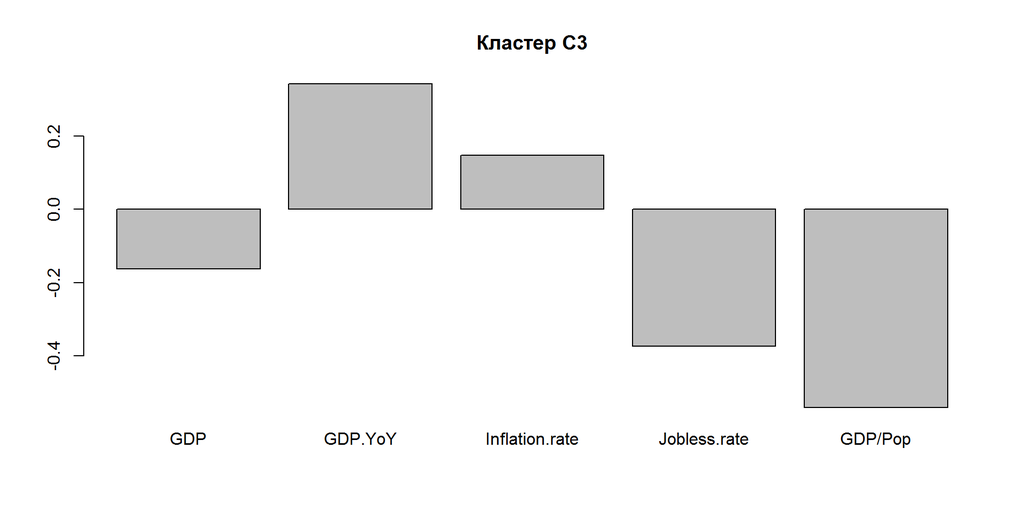

```r
barplot(colMeans(df2[groupsC9==3, 2:6]),main="Кластер C3")
```

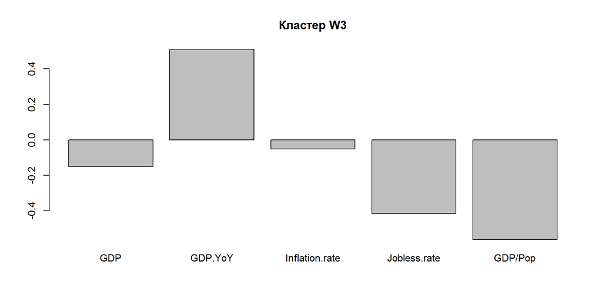

```r
barplot(colMeans(df2[groupsW9==3, 2:6]),main="Кластер W3")
```

```r
colMeans(df1[groupsW5==3, 2:6])
```

```
##            GDP        GDP.YoY Inflation.rate   Jobless.rate        GDP/Pop
##   246.78260870     0.03478261     0.05000000     0.04782609     4.30150111
```

Два метода между собой дают не очень отличающиеся результаты.При этом в новый третий кластер из старого выбраны страны с большим производством, если судить по ВВП и его приросту, но меньшим ВВП на душу населения. Метод Варда выглядит более предпочтительно.

```r
df1[groupsC9==7,1]
```

```
## [1] Oman
## 48 Levels: Afghanistan  Armenia  Azerbaijan  Bahrain  ... Yemen
```

```r
df1[groupsW9==4,1]
```

```
## [1] Iran        Kazakhstan  Oman        Azerbaijan  Nepal
## 48 Levels: Afghanistan  Armenia  Azerbaijan  Bahrain  ... Yemen
```

```r
colMeans(df1[groupsC9==7, 2:6])
```

```
##            GDP        GDP.YoY Inflation.rate   Jobless.rate        GDP/Pop
##       70.00000       -0.14000        0.01000        0.07000       16.86747
```

```r
colMeans(df1[groupsW9==4, 2:6])
```

```
##            GDP        GDP.YoY Inflation.rate   Jobless.rate        GDP/Pop
##     150.600000      -0.030000       0.098000       0.064000       7.819751
```

[figure not shown]

```r
barplot(colMeans(df2[groupsC9==5, 2:6]),main="Кластер C7")
```

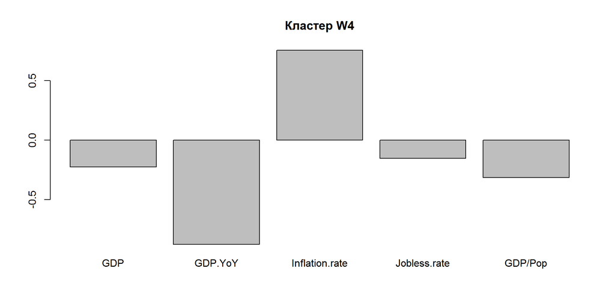

```r
barplot(colMeans(df2[groupsW9==4, 2:6]),main="Кластер W4")
```

```r
colMeans(df1[groupsW5==3, 2:6])
```

```
##            GDP        GDP.YoY Inflation.rate   Jobless.rate        GDP/Pop
##   246.78260870     0.03478261     0.05000000     0.04782609     4.30150111
```

Метод Варда выбрал экономически менее развитые страны из старого третьего кластера. Метод Complete выбрал один Оман.

```r
df1[groupsC9==9,1]
```

```
## [1] Afghanistan  Palestine
## 48 Levels: Afghanistan  Armenia  Azerbaijan  Bahrain  ... Yemen
```

```r
df1[groupsW9==9,1]
```

```
## [1] Afghanistan  Palestine
## 48 Levels: Afghanistan  Armenia  Azerbaijan  Bahrain  ... Yemen
```

```r
colMeans(df1[groupsC9==9, 2:6])
```

```
##            GDP        GDP.YoY Inflation.rate   Jobless.rate        GDP/Pop
##      13.000000       0.050000       0.035000       0.335000       1.098417
```

```r
colMeans(df1[groupsW9==9, 2:6])
```

```
##            GDP        GDP.YoY Inflation.rate   Jobless.rate        GDP/Pop
##      13.000000       0.050000       0.035000       0.335000       1.098417
```

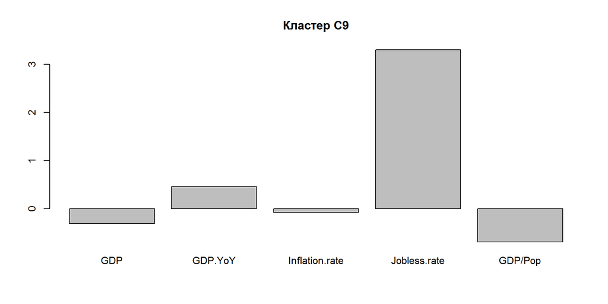

```r
barplot(colMeans(df2[groupsC9==9, 2:6]),main="Кластер C9")
```

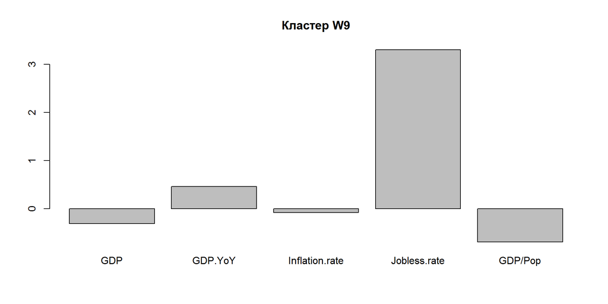

```r
barplot(colMeans(df2[groupsW9==9, 2:6]),main="Кластер W9")
```

Оба метода выделили в новый кластер Афганистан и Палестину из-за огромного уровня безработицы, при прочих ничем не выделяющихся показателей. Также оба метода выделили Макао и Катар из-за чрезвычайно высоких ВВП на душу населения.